# examples_0203

When solving the equation below with standard algebraic methods, two possible solutions are found.

$$8+\sqrt{-3x+10}=-x+12$$

Let $x_1$ and $x_2$ represent the two possible solutions, such that $x_1<x_2$. Find both possible solutions and determine whether each is valid or extraneous.

- $x_1=$
- $x_1$ is solution.
- $x_2=$
- $x_2$ is solution.

$$8+\sqrt{-3x+10}=-x+12$$

Subtract 8 from both sides of the equation.
$$\sqrt{-3x+10}=-x+4$$
Square both sides of the equation. Remember, you'll need to FOIL the right side.
$$-3x+10=x^2-8x+16$$
Subtract $( -3x+10 )$ from both sides.
$$0=x^2-5x+6$$
From here, you can either factor or use quadratic formula. It is easy enough to factor this one.
$$0=(x-2)(x-3)$$
Use the zero-product property to identify the possible solutions are $x_1=2$ and $x_2=3$. Notice we correctly ordered them such that $x_1<x_2$. Now we check which solution is valid by plugging both into the original equation.

Start with possible solution $x=2$
$$8+\sqrt{-3(2)+10}\stackrel{?}{=}-(2)+12$$

$$8+\sqrt{-6+10}\stackrel{?}{=}-2+12$$

$$8+\sqrt{4}\stackrel{?}{=}10$$

$$8+2\stackrel{?}{=}10$$

$$10=10$$
So we see $x=2$ is a valid solution.

Now check possible solution $x=3$
$$8+\sqrt{-3(3)+10}\stackrel{?}{=}-(3)+12$$

$$8+\sqrt{-9+10}\stackrel{?}{=}-3+12$$

$$8+\sqrt{1}\stackrel{?}{=}9$$

$$8+1\stackrel{?}{=}9$$

$$9=9$$
So we see $x=3$ is a valid solution.

When solving the equation below with standard algebraic methods, two possible solutions are found.

$$-7-\sqrt{-8x-28}=-x-9$$

Let $x_1$ and $x_2$ represent the two possible solutions, such that $x_1<x_2$. Find both possible solutions and determine whether each is valid or extraneous.

- $x_1=$
- $x_1$ is solution.
- $x_2=$
- $x_2$ is solution.

$$-7-\sqrt{-8x-28}=-x-9$$

Add 7 to both sides of the equation.
$$-\sqrt{-8x-28}=-x-2$$
Multiply both sides by $-1$.
$$\sqrt{-8x-28}=x+2$$
Square both sides of the equation. Remember, you'll need to FOIL the right side.
$$-8x-28=x^2+4x+4$$
Subtract $( -8x-28 )$ from both sides.
$$0=x^2+12x+32$$
From here, you can either factor or use quadratic formula. It is easy enough to factor this one.
$$0=(x+8)(x+4)$$
Use the zero-product property to identify the possible solutions are $x_1=-8$ and $x_2=-4$. Notice we correctly ordered them such that $x_1<x_2$. Now we check which solution is valid by plugging both into the original equation.

Start with possible solution $x=-8$
$$-7-\sqrt{-8(-8)-28}\stackrel{?}{=}-(-8)-9$$

$$-7-\sqrt{64-28}\stackrel{?}{=}8-9$$

$$-7-\sqrt{36}\stackrel{?}{=}-1$$

$$-7-6\stackrel{?}{=}-1$$

$$-13\ne -1$$
So we see $x=-8$ is an extraneous solution.

Now check possible solution $x=-4$
$$-7-\sqrt{-8(-4)-28}\stackrel{?}{=}-(-4)-9$$

$$-7-\sqrt{32-28}\stackrel{?}{=}4-9$$

$$-7-\sqrt{4}\stackrel{?}{=}-5$$

$$-7-2\stackrel{?}{=}-5$$

$$-9\ne -5$$
So we see $x=-4$ is an extraneous solution.

When solving the equation below with standard algebraic methods, two possible solutions are found.

$$9-\sqrt{-3x+25}=-x+16$$

Let $x_1$ and $x_2$ represent the two possible solutions, such that $x_1<x_2$. Find both possible solutions and determine whether each is valid or extraneous.

- $x_1=$
- $x_1$ is solution.
- $x_2=$
- $x_2$ is solution.

$$9-\sqrt{-3x+25}=-x+16$$

Subtract 9 from both sides of the equation.
$$-\sqrt{-3x+25}=-x+7$$
Multiply both sides by $-1$.
$$\sqrt{-3x+25}=x-7$$
Square both sides of the equation. Remember, you'll need to FOIL the right side.
$$-3x+25=x^2-14x+49$$
Subtract $( -3x+25 )$ from both sides.
$$0=x^2-11x+24$$
From here, you can either factor or use quadratic formula. It is easy enough to factor this one.
$$0=(x-3)(x-8)$$
Use the zero-product property to identify the possible solutions are $x_1=3$ and $x_2=8$. Notice we correctly ordered them such that $x_1<x_2$. Now we check which solution is valid by plugging both into the original equation.

Start with possible solution $x=3$
$$9-\sqrt{-3(3)+25}\stackrel{?}{=}-(3)+16$$

$$9-\sqrt{-9+25}\stackrel{?}{=}-3+16$$

$$9-\sqrt{16}\stackrel{?}{=}13$$

$$9-4\stackrel{?}{=}13$$

$$5\ne 13$$
So we see $x=3$ is an extraneous solution.

Now check possible solution $x=8$
$$9-\sqrt{-3(8)+25}\stackrel{?}{=}-(8)+16$$

$$9-\sqrt{-24+25}\stackrel{?}{=}-8+16$$

$$9-\sqrt{1}\stackrel{?}{=}8$$

$$9-1\stackrel{?}{=}8$$

$$8=8$$
So we see $x=8$ is a valid solution.

When solving the equation below with standard algebraic methods, two possible solutions are found.

$$-8+\sqrt{8x-31}=-x-6$$

Let $x_1$ and $x_2$ represent the two possible solutions, such that $x_1<x_2$. Find both possible solutions and determine whether each is valid or extraneous.

- $x_1=$
- $x_1$ is solution.
- $x_2=$
- $x_2$ is solution.

$$-8+\sqrt{8x-31}=-x-6$$

Add 8 to both sides of the equation.
$$\sqrt{8x-31}=-x+2$$
Square both sides of the equation. Remember, you'll need to FOIL the right side.
$$8x-31=x^2-4x+4$$
Subtract $( 8x-31 )$ from both sides.
$$0=x^2-12x+35$$
From here, you can either factor or use quadratic formula. It is easy enough to factor this one.
$$0=(x-5)(x-7)$$
Use the zero-product property to identify the possible solutions are $x_1=5$ and $x_2=7$. Notice we correctly ordered them such that $x_1<x_2$. Now we check which solution is valid by plugging both into the original equation.

Start with possible solution $x=5$
$$-8+\sqrt{8(5)-31}\stackrel{?}{=}-(5)-6$$

$$-8+\sqrt{40-31}\stackrel{?}{=}-5-6$$

$$-8+\sqrt{9}\stackrel{?}{=}-11$$

$$-8+3\stackrel{?}{=}-11$$

$$-5\ne -11$$
So we see $x=5$ is an extraneous solution.

Now check possible solution $x=7$
$$-8+\sqrt{8(7)-31}\stackrel{?}{=}-(7)-6$$

$$-8+\sqrt{56-31}\stackrel{?}{=}-7-6$$

$$-8+\sqrt{25}\stackrel{?}{=}-13$$

$$-8+5\stackrel{?}{=}-13$$

$$-3\ne -13$$
So we see $x=7$ is an extraneous solution.

When solving the equation below with standard algebraic methods, two possible solutions are found.

$$9-\sqrt{-8x+73}=x+4$$

Let $x_1$ and $x_2$ represent the two possible solutions, such that $x_1<x_2$. Find both possible solutions and determine whether each is valid or extraneous.

- $x_1=$
- $x_1$ is solution.
- $x_2=$
- $x_2$ is solution.

$$9-\sqrt{-8x+73}=x+4$$

Subtract 9 from both sides of the equation.
$$-\sqrt{-8x+73}=x-5$$
Multiply both sides by $-1$.
$$\sqrt{-8x+73}=-x+5$$
Square both sides of the equation. Remember, you'll need to FOIL the right side.
$$-8x+73=x^2-10x+25$$
Subtract $( -8x+73 )$ from both sides.
$$0=x^2-2x-48$$
From here, you can either factor or use quadratic formula. It is easy enough to factor this one.
$$0=(x+6)(x-8)$$
Use the zero-product property to identify the possible solutions are $x_1=-6$ and $x_2=8$. Notice we correctly ordered them such that $x_1<x_2$. Now we check which solution is valid by plugging both into the original equation.

Start with possible solution $x=-6$
$$9-\sqrt{-8(-6)+73}\stackrel{?}{=}(-6)+4$$

$$9-\sqrt{48+73}\stackrel{?}{=}-6+4$$

$$9-\sqrt{121}\stackrel{?}{=}-2$$

$$9-11\stackrel{?}{=}-2$$

$$-2=-2$$
So we see $x=-6$ is a valid solution.

Now check possible solution $x=8$
$$9-\sqrt{-8(8)+73}\stackrel{?}{=}(8)+4$$

$$9-\sqrt{-64+73}\stackrel{?}{=}8+4$$

$$9-\sqrt{9}\stackrel{?}{=}12$$

$$9-3\stackrel{?}{=}12$$

$$6\ne 12$$
So we see $x=8$ is an extraneous solution.

When solving the equation below with standard algebraic methods, two possible solutions are found.

$$6+\sqrt{-9x-17}=x+7$$

Let $x_1$ and $x_2$ represent the two possible solutions, such that $x_1<x_2$. Find both possible solutions and determine whether each is valid or extraneous.

- $x_1=$
- $x_1$ is solution.
- $x_2=$
- $x_2$ is solution.

$$6+\sqrt{-9x-17}=x+7$$

Subtract 6 from both sides of the equation.
$$\sqrt{-9x-17}=x+1$$
Square both sides of the equation. Remember, you'll need to FOIL the right side.
$$-9x-17=x^2+2x+1$$
Subtract $( -9x-17 )$ from both sides.
$$0=x^2+11x+18$$
From here, you can either factor or use quadratic formula. It is easy enough to factor this one.
$$0=(x+9)(x+2)$$
Use the zero-product property to identify the possible solutions are $x_1=-9$ and $x_2=-2$. Notice we correctly ordered them such that $x_1<x_2$. Now we check which solution is valid by plugging both into the original equation.

Start with possible solution $x=-9$
$$6+\sqrt{-9(-9)-17}\stackrel{?}{=}(-9)+7$$

$$6+\sqrt{81-17}\stackrel{?}{=}-9+7$$

$$6+\sqrt{64}\stackrel{?}{=}-2$$

$$6+8\stackrel{?}{=}-2$$

$$14\ne -2$$
So we see $x=-9$ is an extraneous solution.

Now check possible solution $x=-2$
$$6+\sqrt{-9(-2)-17}\stackrel{?}{=}(-2)+7$$

$$6+\sqrt{18-17}\stackrel{?}{=}-2+7$$

$$6+\sqrt{1}\stackrel{?}{=}5$$

$$6+1\stackrel{?}{=}5$$

$$7\ne 5$$
So we see $x=-2$ is an extraneous solution.

When solving the equation below with standard algebraic methods, two possible solutions are found.

$$6+\sqrt{3x-3}=-x+7$$

Let $x_1$ and $x_2$ represent the two possible solutions, such that $x_1<x_2$. Find both possible solutions and determine whether each is valid or extraneous.

- $x_1=$
- $x_1$ is solution.
- $x_2=$
- $x_2$ is solution.

$$6+\sqrt{3x-3}=-x+7$$

Subtract 6 from both sides of the equation.
$$\sqrt{3x-3}=-x+1$$
Square both sides of the equation. Remember, you'll need to FOIL the right side.
$$3x-3=x^2-2x+1$$
Subtract $( 3x-3 )$ from both sides.
$$0=x^2-5x+4$$
From here, you can either factor or use quadratic formula. It is easy enough to factor this one.
$$0=(x-1)(x-4)$$
Use the zero-product property to identify the possible solutions are $x_1=1$ and $x_2=4$. Notice we correctly ordered them such that $x_1<x_2$. Now we check which solution is valid by plugging both into the original equation.

Start with possible solution $x=1$
$$6+\sqrt{3(1)-3}\stackrel{?}{=}-(1)+7$$

$$6+\sqrt{3-3}\stackrel{?}{=}-1+7$$

$$6+\sqrt{0}\stackrel{?}{=}6$$

$$6+0\stackrel{?}{=}6$$

$$6=6$$
So we see $x=1$ is a valid solution.

Now check possible solution $x=4$
$$6+\sqrt{3(4)-3}\stackrel{?}{=}-(4)+7$$

$$6+\sqrt{12-3}\stackrel{?}{=}-4+7$$

$$6+\sqrt{9}\stackrel{?}{=}3$$

$$6+3\stackrel{?}{=}3$$

$$9\ne 3$$
So we see $x=4$ is an extraneous solution.

When solving the equation below with standard algebraic methods, two possible solutions are found.

$$6+\sqrt{-8x-23}=x+8$$

Let $x_1$ and $x_2$ represent the two possible solutions, such that $x_1<x_2$. Find both possible solutions and determine whether each is valid or extraneous.

- $x_1=$
- $x_1$ is solution.
- $x_2=$
- $x_2$ is solution.

$$6+\sqrt{-8x-23}=x+8$$

Subtract 6 from both sides of the equation.
$$\sqrt{-8x-23}=x+2$$
Square both sides of the equation. Remember, you'll need to FOIL the right side.
$$-8x-23=x^2+4x+4$$
Subtract $( -8x-23 )$ from both sides.
$$0=x^2+12x+27$$
From here, you can either factor or use quadratic formula. It is easy enough to factor this one.
$$0=(x+9)(x+3)$$
Use the zero-product property to identify the possible solutions are $x_1=-9$ and $x_2=-3$. Notice we correctly ordered them such that $x_1<x_2$. Now we check which solution is valid by plugging both into the original equation.

Start with possible solution $x=-9$
$$6+\sqrt{-8(-9)-23}\stackrel{?}{=}(-9)+8$$

$$6+\sqrt{72-23}\stackrel{?}{=}-9+8$$

$$6+\sqrt{49}\stackrel{?}{=}-1$$

$$6+7\stackrel{?}{=}-1$$

$$13\ne -1$$
So we see $x=-9$ is an extraneous solution.

Now check possible solution $x=-3$
$$6+\sqrt{-8(-3)-23}\stackrel{?}{=}(-3)+8$$

$$6+\sqrt{24-23}\stackrel{?}{=}-3+8$$

$$6+\sqrt{1}\stackrel{?}{=}5$$

$$6+1\stackrel{?}{=}5$$

$$7\ne 5$$
So we see $x=-3$ is an extraneous solution.

When solving the equation below with standard algebraic methods, two possible solutions are found.

$$-8+\sqrt{6x-11}=-x-7$$

Let $x_1$ and $x_2$ represent the two possible solutions, such that $x_1<x_2$. Find both possible solutions and determine whether each is valid or extraneous.

- $x_1=$
- $x_1$ is solution.
- $x_2=$
- $x_2$ is solution.

$$-8+\sqrt{6x-11}=-x-7$$

Add 8 to both sides of the equation.
$$\sqrt{6x-11}=-x+1$$
Square both sides of the equation. Remember, you'll need to FOIL the right side.
$$6x-11=x^2-2x+1$$
Subtract $( 6x-11 )$ from both sides.
$$0=x^2-8x+12$$
From here, you can either factor or use quadratic formula. It is easy enough to factor this one.
$$0=(x-2)(x-6)$$
Use the zero-product property to identify the possible solutions are $x_1=2$ and $x_2=6$. Notice we correctly ordered them such that $x_1<x_2$. Now we check which solution is valid by plugging both into the original equation.

Start with possible solution $x=2$
$$-8+\sqrt{6(2)-11}\stackrel{?}{=}-(2)-7$$

$$-8+\sqrt{12-11}\stackrel{?}{=}-2-7$$

$$-8+\sqrt{1}\stackrel{?}{=}-9$$

$$-8+1\stackrel{?}{=}-9$$

$$-7\ne -9$$
So we see $x=2$ is an extraneous solution.

Now check possible solution $x=6$
$$-8+\sqrt{6(6)-11}\stackrel{?}{=}-(6)-7$$

$$-8+\sqrt{36-11}\stackrel{?}{=}-6-7$$

$$-8+\sqrt{25}\stackrel{?}{=}-13$$

$$-8+5\stackrel{?}{=}-13$$

$$-3\ne -13$$
So we see $x=6$ is an extraneous solution.

When solving the equation below with standard algebraic methods, two possible solutions are found.

$$2-\sqrt{-8x+52}=x-6$$

Let $x_1$ and $x_2$ represent the two possible solutions, such that $x_1<x_2$. Find both possible solutions and determine whether each is valid or extraneous.

- $x_1=$
- $x_1$ is solution.
- $x_2=$
- $x_2$ is solution.

$$2-\sqrt{-8x+52}=x-6$$

Subtract 2 from both sides of the equation.
$$-\sqrt{-8x+52}=x-8$$
Multiply both sides by $-1$.
$$\sqrt{-8x+52}=-x+8$$
Square both sides of the equation. Remember, you'll need to FOIL the right side.
$$-8x+52=x^2-16x+64$$
Subtract $( -8x+52 )$ from both sides.
$$0=x^2-8x+12$$
From here, you can either factor or use quadratic formula. It is easy enough to factor this one.
$$0=(x-2)(x-6)$$
Use the zero-product property to identify the possible solutions are $x_1=2$ and $x_2=6$. Notice we correctly ordered them such that $x_1<x_2$. Now we check which solution is valid by plugging both into the original equation.

Start with possible solution $x=2$
$$2-\sqrt{-8(2)+52}\stackrel{?}{=}(2)-6$$

$$2-\sqrt{-16+52}\stackrel{?}{=}2-6$$

$$2-\sqrt{36}\stackrel{?}{=}-4$$

$$2-6\stackrel{?}{=}-4$$

$$-4=-4$$
So we see $x=2$ is a valid solution.

Now check possible solution $x=6$
$$2-\sqrt{-8(6)+52}\stackrel{?}{=}(6)-6$$

$$2-\sqrt{-48+52}\stackrel{?}{=}6-6$$

$$2-\sqrt{4}\stackrel{?}{=}0$$

$$2-2\stackrel{?}{=}0$$

$$0=0$$
So we see $x=6$ is a valid solution.

A transformed square-root function, $y=f(x)$, is graphed below. A linear function, $y=L(x)$, is not shown, but it goes through point $(-6,-3)$ and has a slope of $\frac{-1}{2}$.

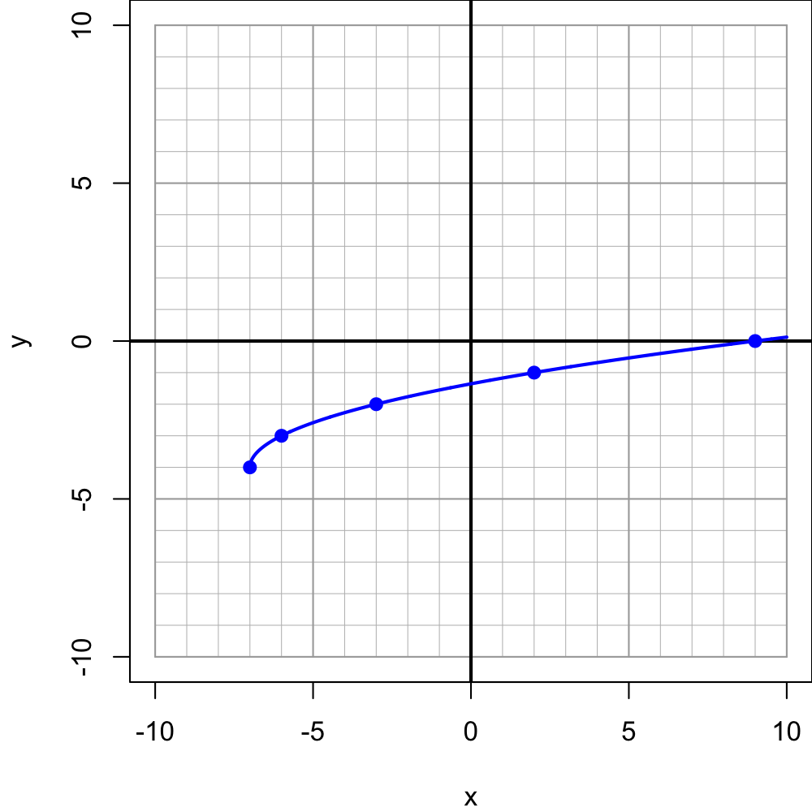

If standard algebraic steps were used to find $x$ values that satisfy equation $f(x)=L(x)$, what extraneous solution would be found?

You should be able to complete the picture. Use symmetry to complete the parabola, and use the slope to extend the line.

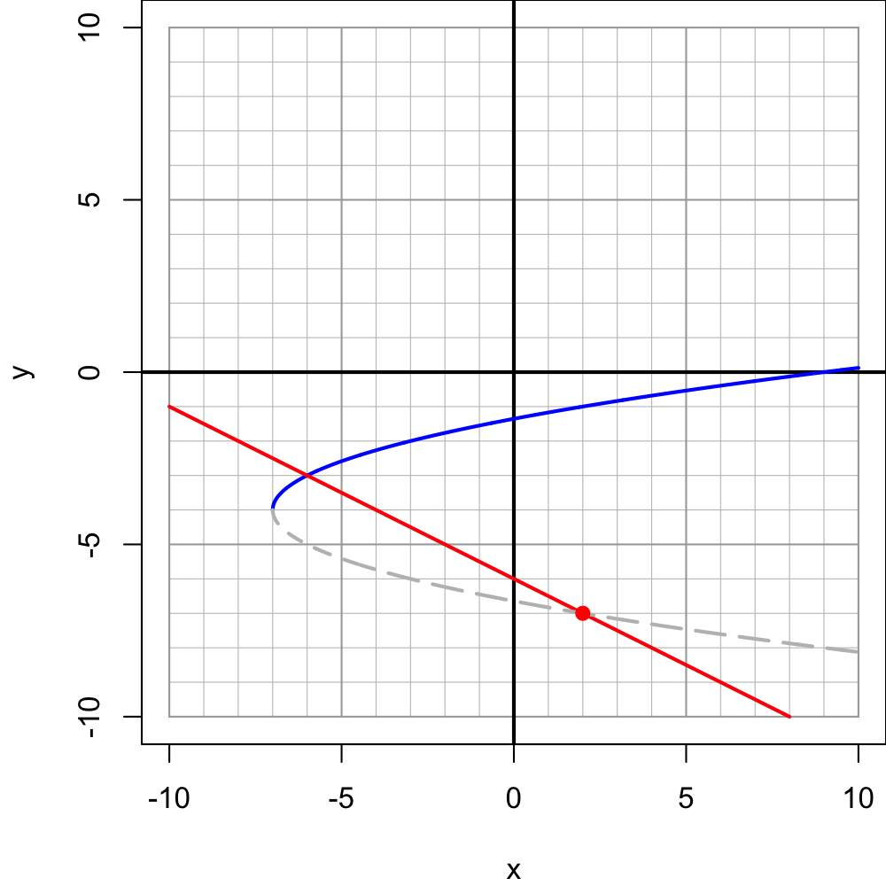

The intersection of the line with the second half of the parabola is at point $(2,-7)$. Thus the extraneous solution is $x=2$.

A transformed square-root function, $y=f(x)$, is graphed below. A linear function, $y=L(x)$, is not shown, but it goes through point $(-3,-7)$ and has a slope of $\frac{1}{2}$.

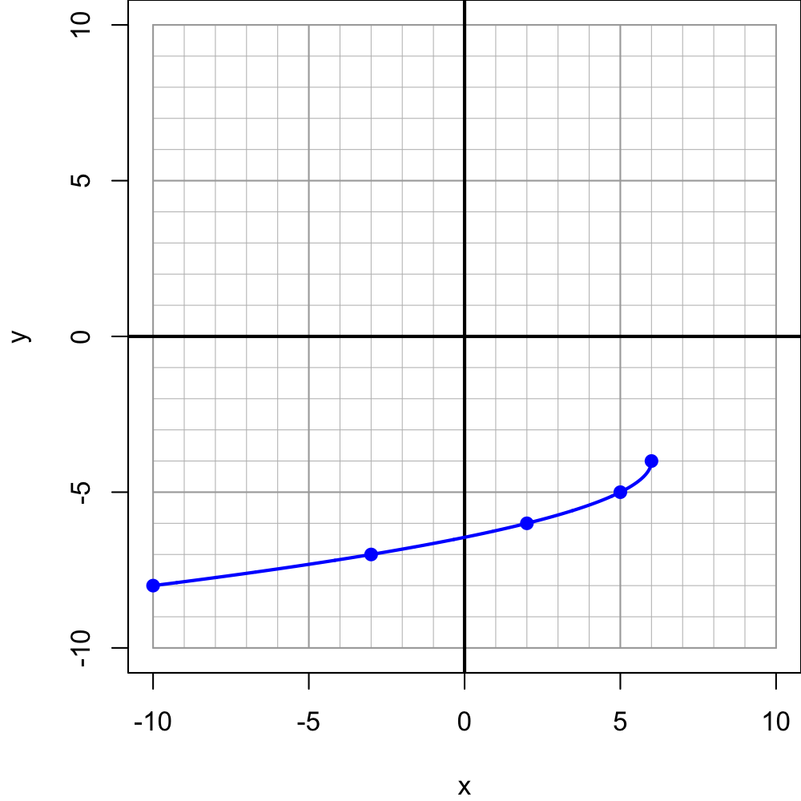

If standard algebraic steps were used to find $x$ values that satisfy equation $f(x)=L(x)$, what extraneous solution would be found?

You should be able to complete the picture. Use symmetry to complete the parabola, and use the slope to extend the line.

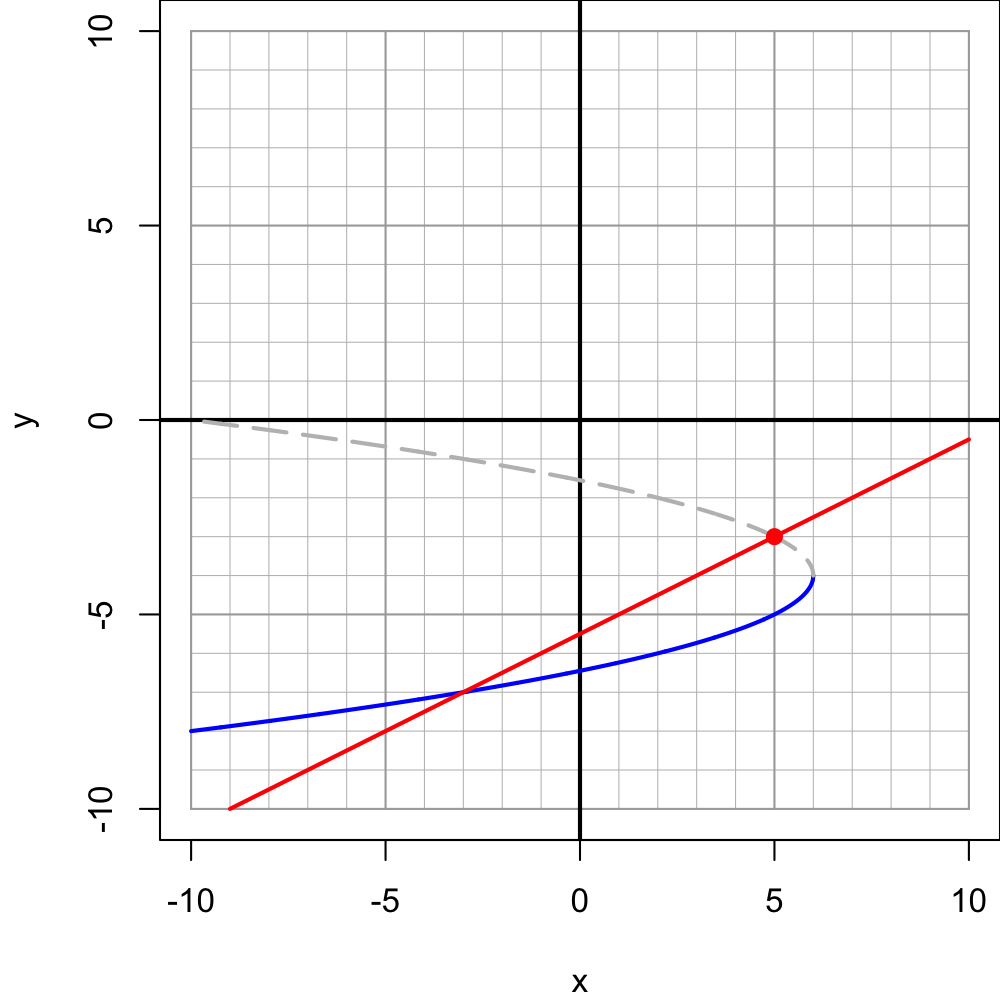

The intersection of the line with the second half of the parabola is at point $(5,-3)$. Thus the extraneous solution is $x=5$.

A transformed square-root function, $y=f(x)$, is graphed below. A linear function, $y=L(x)$, is not shown, but it goes through point $(-3,4)$ and has a slope of $\frac{-1}{2}$.

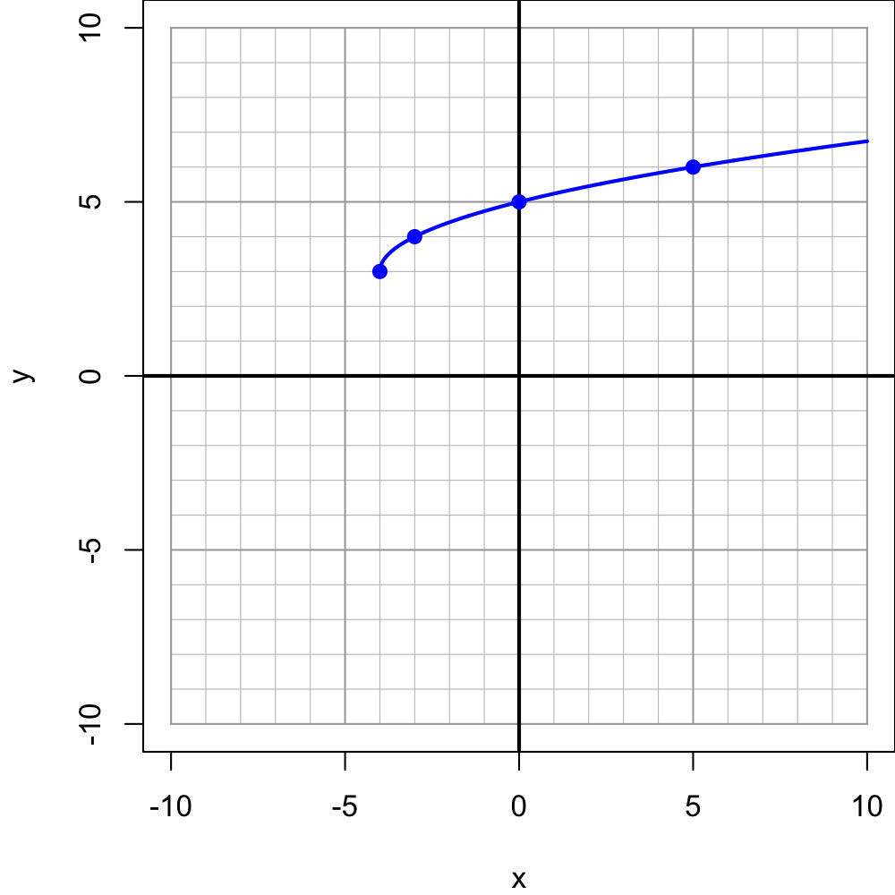

If standard algebraic steps were used to find $x$ values that satisfy equation $f(x)=L(x)$, what extraneous solution would be found?

You should be able to complete the picture. Use symmetry to complete the parabola, and use the slope to extend the line.

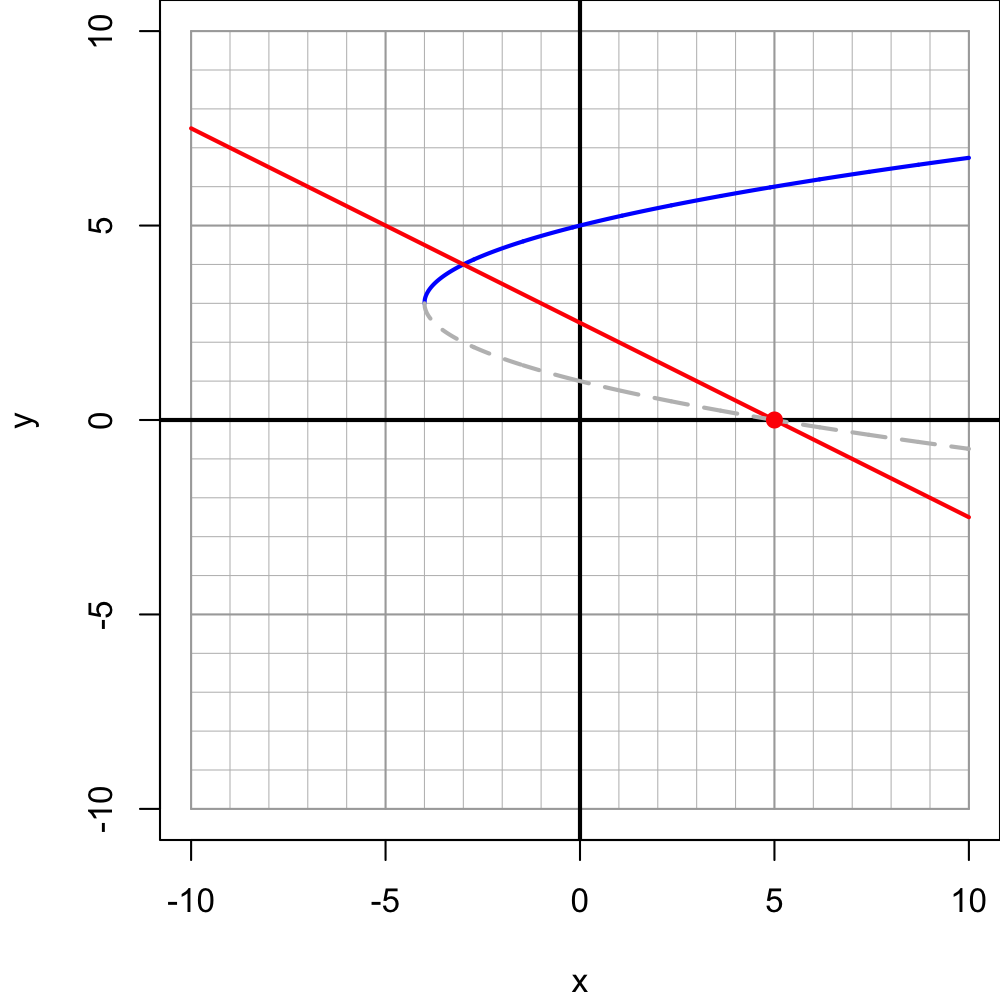

The intersection of the line with the second half of the parabola is at point $(5,0)$. Thus the extraneous solution is $x=5$.

A transformed square-root function, $y=f(x)$, is graphed below. A linear function, $y=L(x)$, is not shown, but it goes through point $(-4,-5)$ and has a slope of $2$.

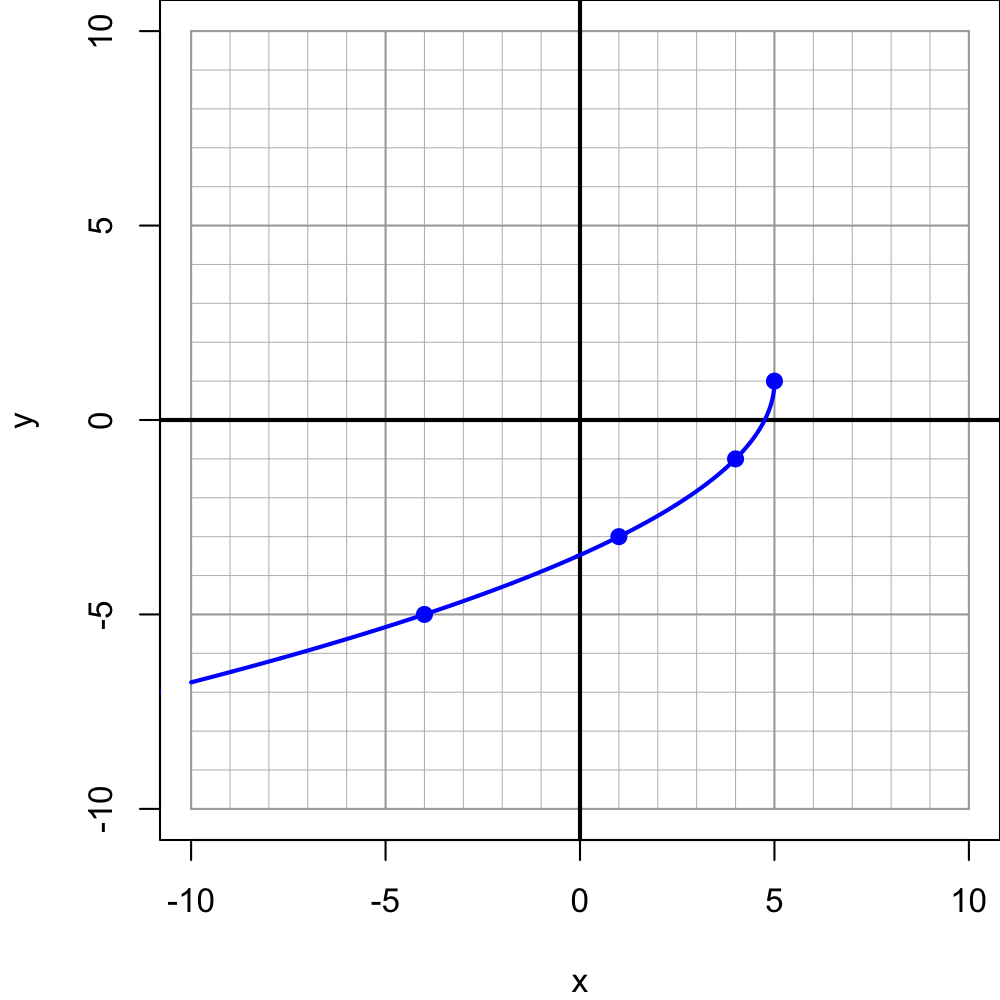

If standard algebraic steps were used to find $x$ values that satisfy equation $f(x)=L(x)$, what extraneous solution would be found?

You should be able to complete the picture. Use symmetry to complete the parabola, and use the slope to extend the line.

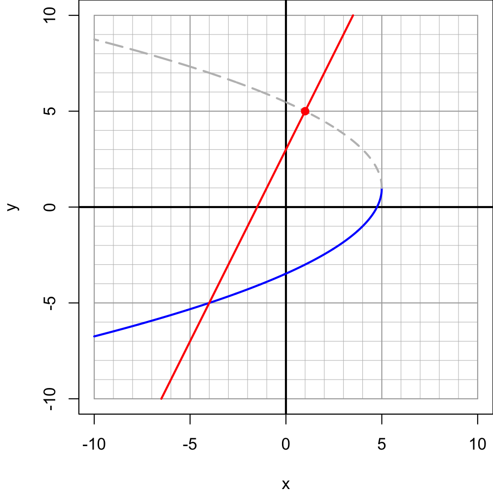

The intersection of the line with the second half of the parabola is at point $(1,5)$. Thus the extraneous solution is $x=1$.

A transformed square-root function, $y=f(x)$, is graphed below. A linear function, $y=L(x)$, is not shown, but it goes through point $(-2,2)$ and has a slope of $1$.

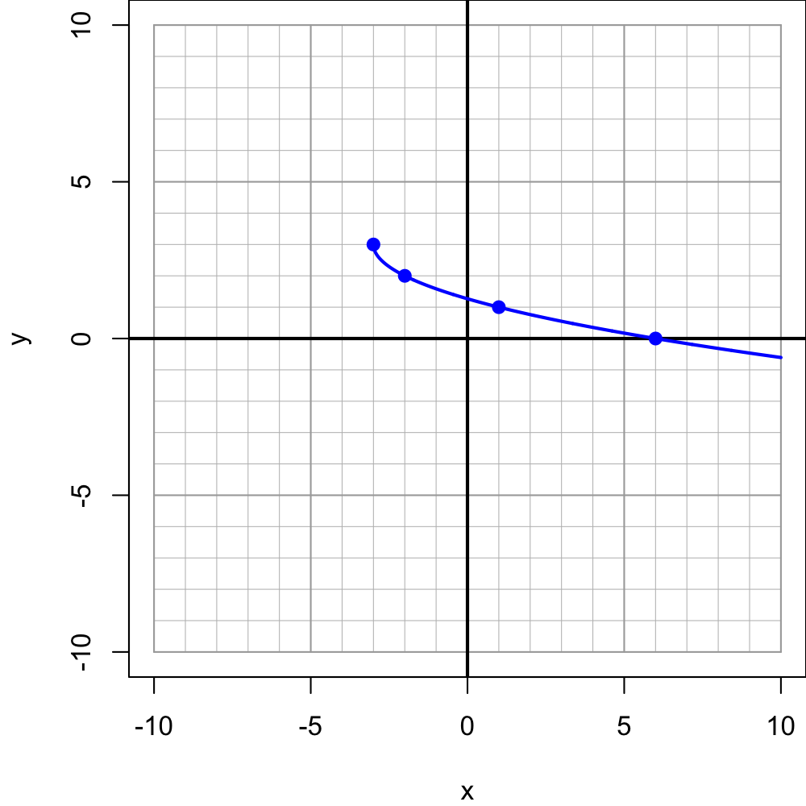

If standard algebraic steps were used to find $x$ values that satisfy equation $f(x)=L(x)$, what extraneous solution would be found?

You should be able to complete the picture. Use symmetry to complete the parabola, and use the slope to extend the line.

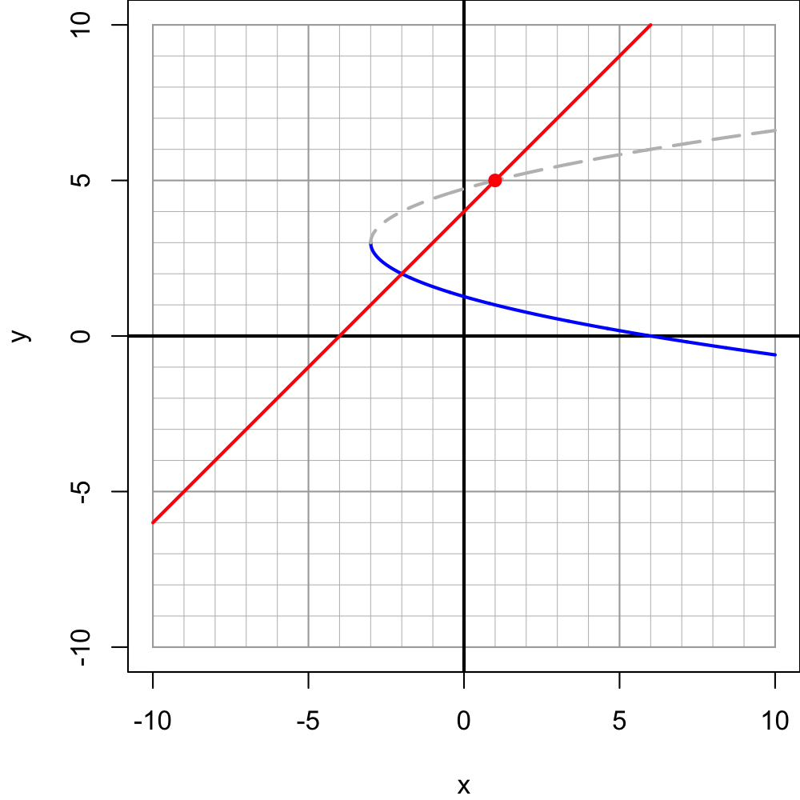

The intersection of the line with the second half of the parabola is at point $(1,5)$. Thus the extraneous solution is $x=1$.

A transformed square-root function, $y=f(x)$, is graphed below. A linear function, $y=L(x)$, is not shown, but it goes through point $(3,-9)$ and has a slope of $-2$.

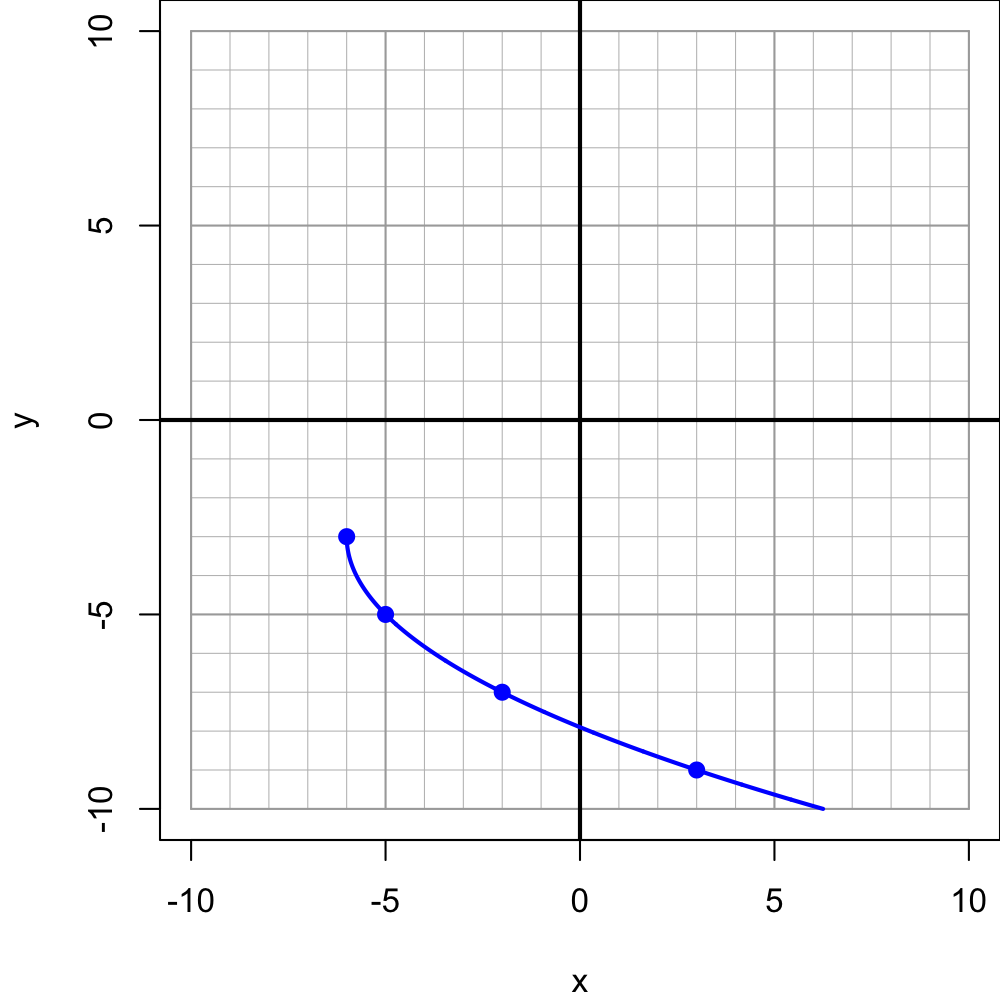

If standard algebraic steps were used to find $x$ values that satisfy equation $f(x)=L(x)$, what extraneous solution would be found?

You should be able to complete the picture. Use symmetry to complete the parabola, and use the slope to extend the line.

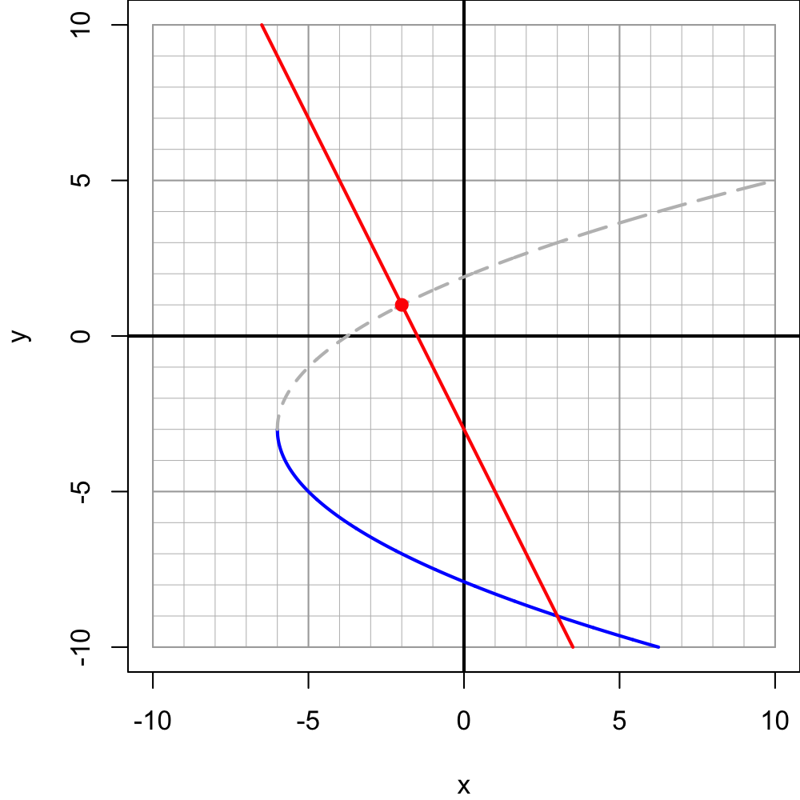

The intersection of the line with the second half of the parabola is at point $(-2,1)$. Thus the extraneous solution is $x=-2$.

A transformed square-root function, $y=f(x)$, is graphed below. A linear function, $y=L(x)$, is not shown, but it goes through point $(-3,0)$ and has a slope of $-1$.

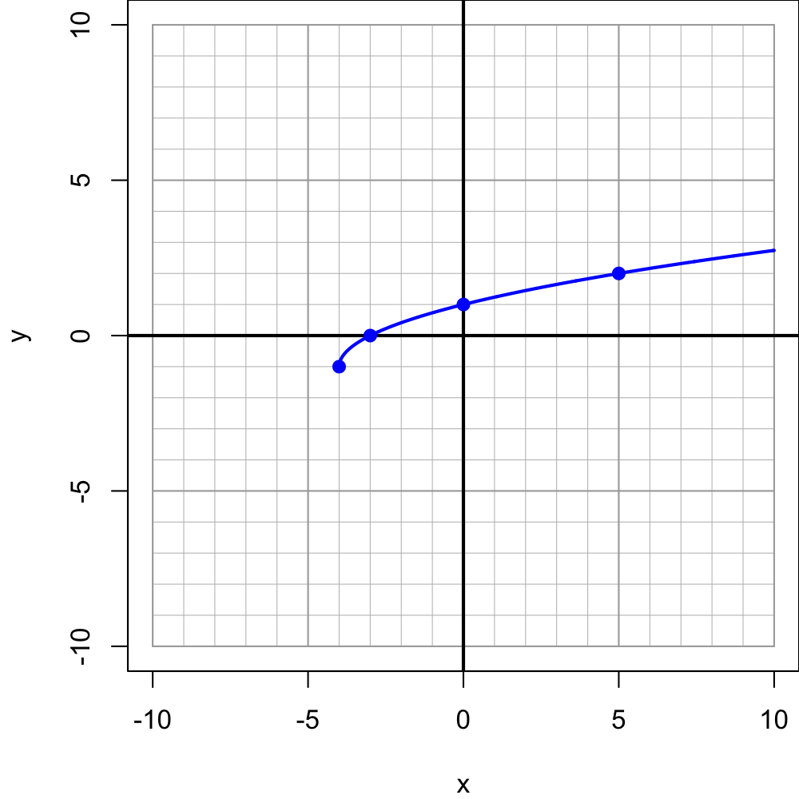

If standard algebraic steps were used to find $x$ values that satisfy equation $f(x)=L(x)$, what extraneous solution would be found?

You should be able to complete the picture. Use symmetry to complete the parabola, and use the slope to extend the line.

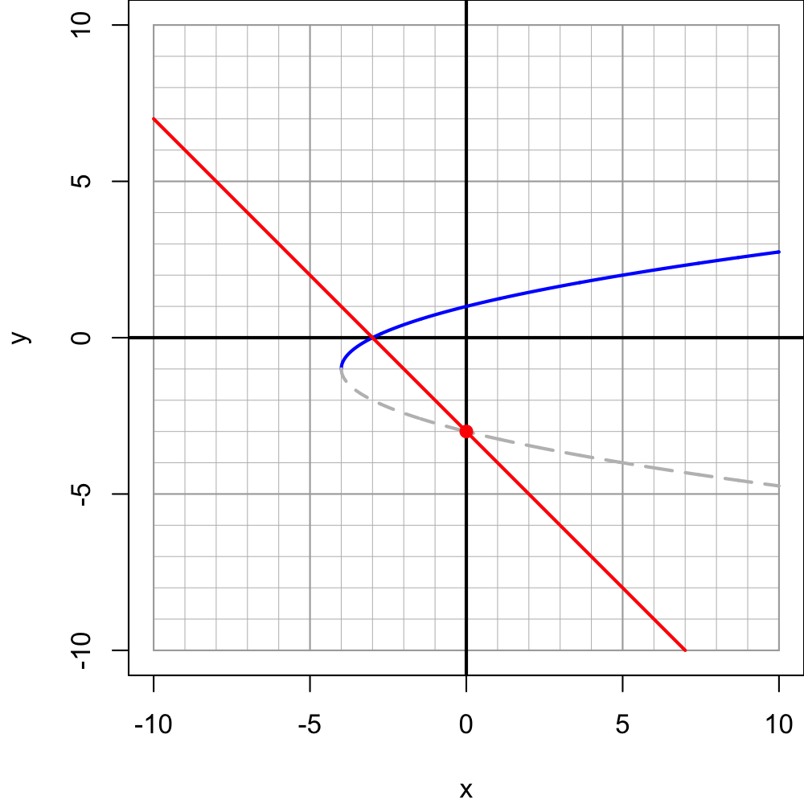

The intersection of the line with the second half of the parabola is at point $(0,-3)$. Thus the extraneous solution is $x=0$.

A transformed square-root function, $y=f(x)$, is graphed below. A linear function, $y=L(x)$, is not shown, but it goes through point $(2,1)$ and has a slope of $\frac{-1}{2}$.

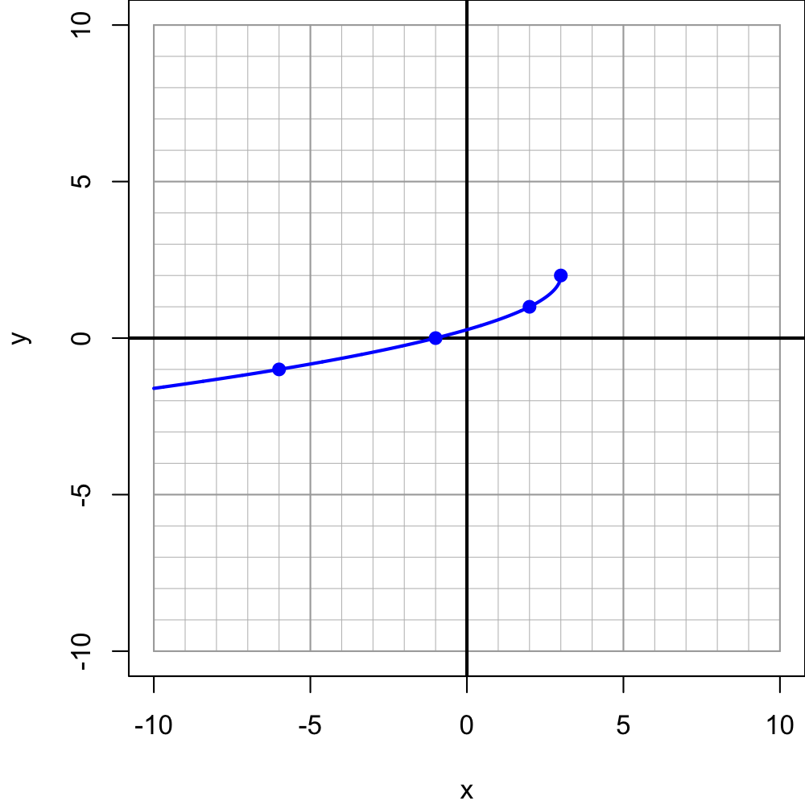

If standard algebraic steps were used to find $x$ values that satisfy equation $f(x)=L(x)$, what extraneous solution would be found?

You should be able to complete the picture. Use symmetry to complete the parabola, and use the slope to extend the line.

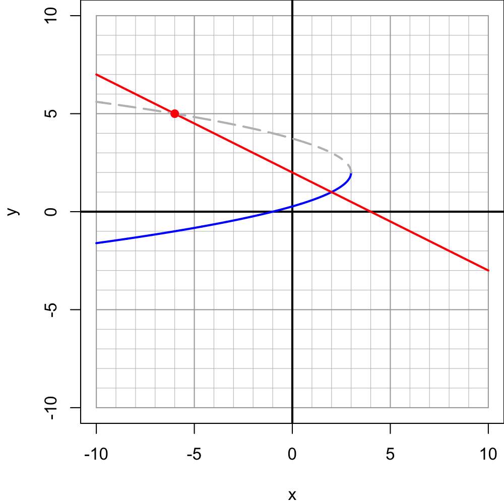

The intersection of the line with the second half of the parabola is at point $(-6,5)$. Thus the extraneous solution is $x=-6$.

A transformed square-root function, $y=f(x)$, is graphed below. A linear function, $y=L(x)$, is not shown, but it goes through point $(3,-3)$ and has a slope of $1$.

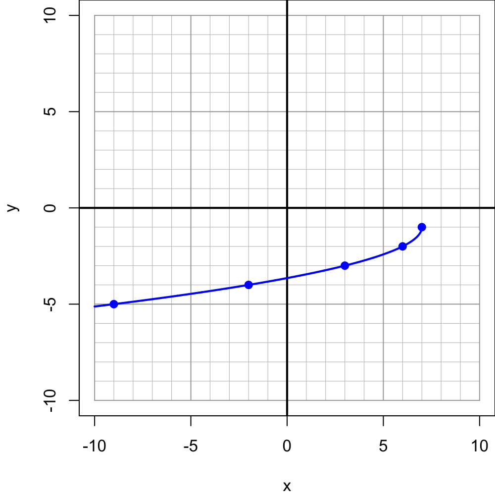

If standard algebraic steps were used to find $x$ values that satisfy equation $f(x)=L(x)$, what extraneous solution would be found?

You should be able to complete the picture. Use symmetry to complete the parabola, and use the slope to extend the line.

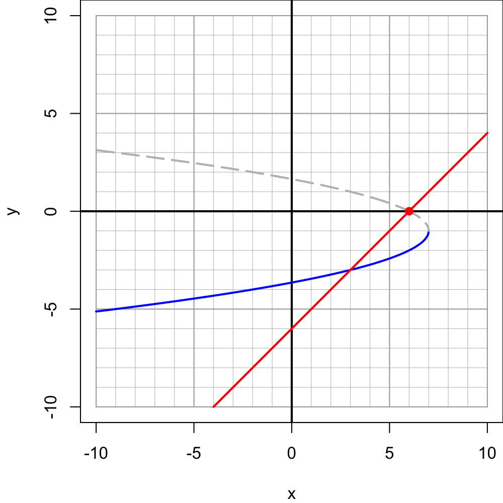

The intersection of the line with the second half of the parabola is at point $(6,0)$. Thus the extraneous solution is $x=6$.

A transformed square-root function, $y=f(x)$, is graphed below. A linear function, $y=L(x)$, is not shown, but it goes through point $(2,0)$ and has a slope of $\frac{-1}{2}$.

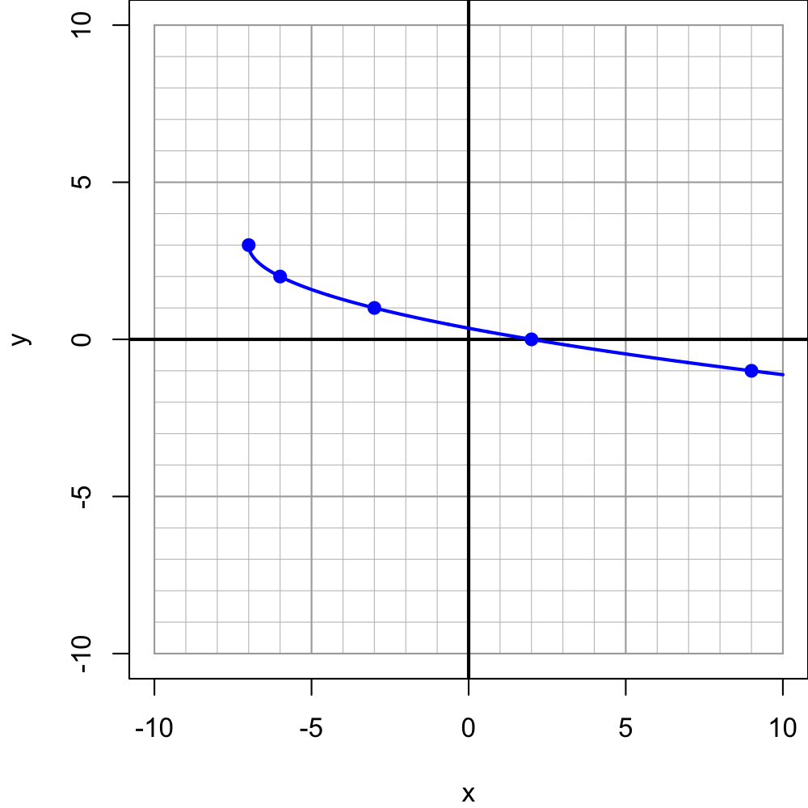

If standard algebraic steps were used to find $x$ values that satisfy equation $f(x)=L(x)$, what extraneous solution would be found?

You should be able to complete the picture. Use symmetry to complete the parabola, and use the slope to extend the line.

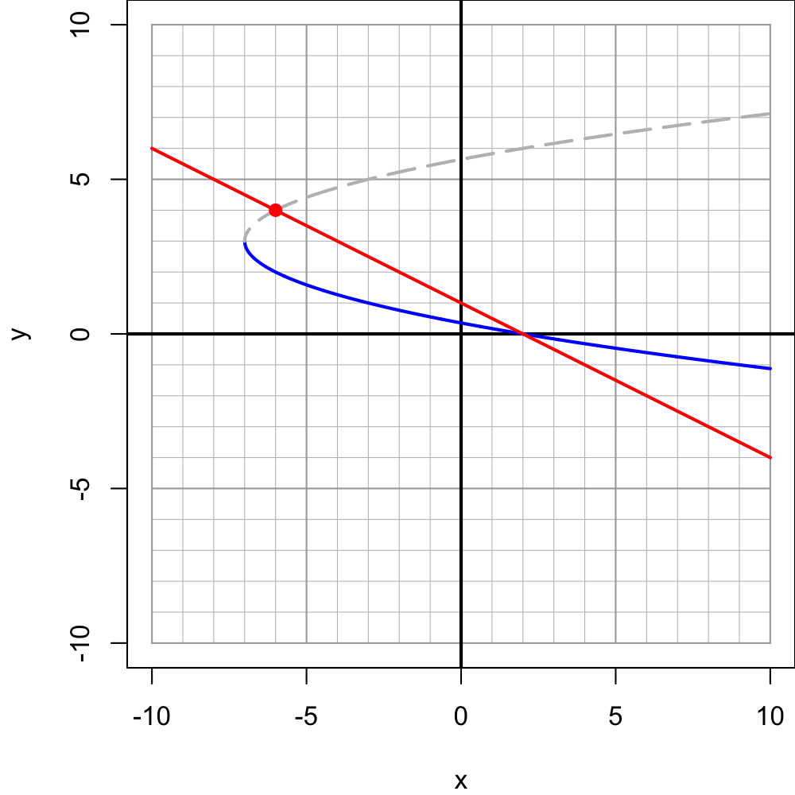

The intersection of the line with the second half of the parabola is at point $(-6,4)$. Thus the extraneous solution is $x=-6$.

A transformed square-root function, $y=f(x)$, is graphed below. A linear function, $y=L(x)$, is not shown, but it goes through point $(5,5)$ and has a slope of $1$.

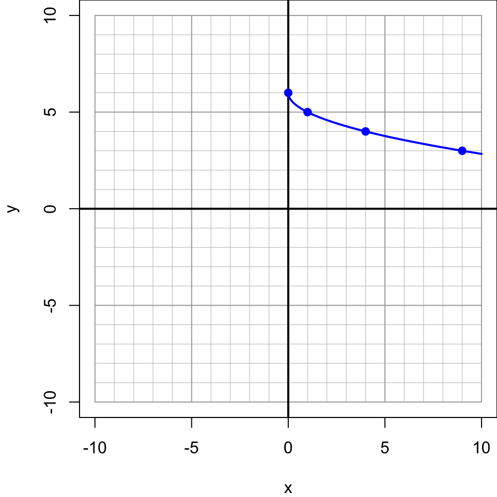

If standard algebraic steps were used to find $x$ values that satisfy equation $f(x)=L(x)$, what valid solution and what extraneous solution would be found?

- Valid:
- Extraneous:

You should be able to complete the picture. Use symmetry to complete the parabola, and use the slope to extend the line.

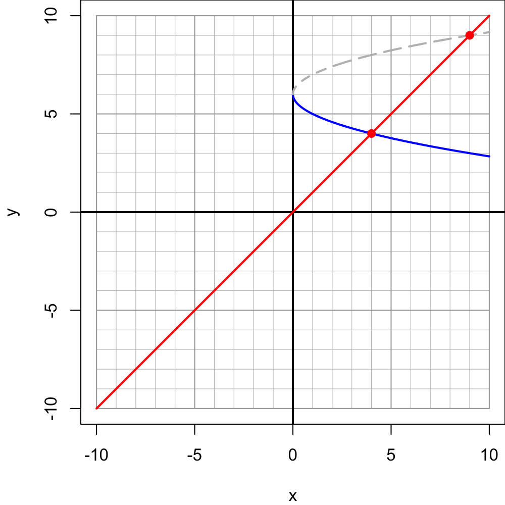

The intersection of the line with the valid half of the parabola is at point $(4,4)$. Thus the valid solution is $x=4$.

The intersection of the line with the extraneous half of the parabola is at point $(9,9)$. Thus the extraneous solution is $x=9$.

A transformed square-root function, $y=f(x)$, is graphed below. A linear function, $y=L(x)$, is not shown, but it goes through point $(5,-8)$ and has a slope of $-2$.

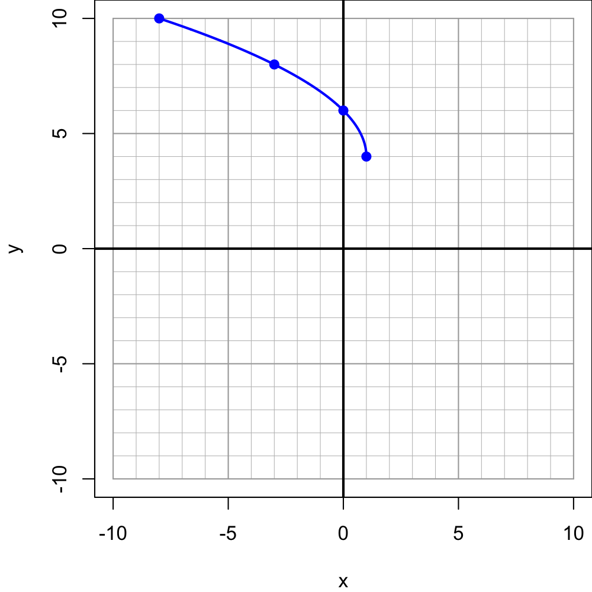

If standard algebraic steps were used to find $x$ values that satisfy equation $f(x)=L(x)$, what valid solution and what extraneous solution would be found?

- Valid:
- Extraneous:

You should be able to complete the picture. Use symmetry to complete the parabola, and use the slope to extend the line.

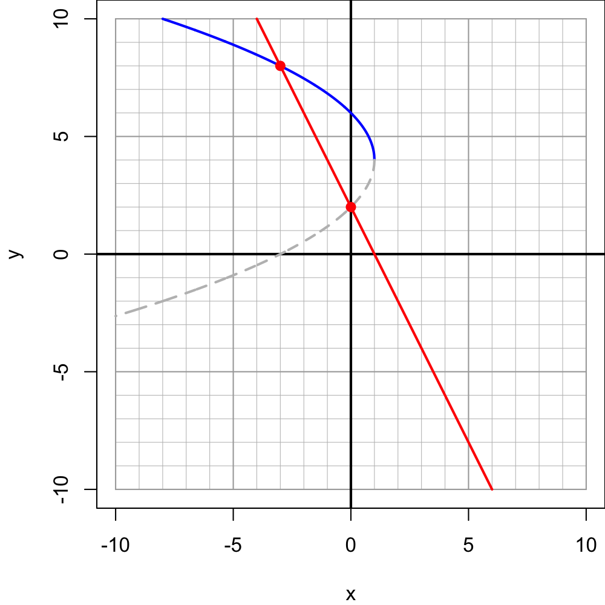

The intersection of the line with the valid half of the parabola is at point $(-3,8)$. Thus the valid solution is $x=-3$.

The intersection of the line with the extraneous half of the parabola is at point $(0,2)$. Thus the extraneous solution is $x=0$.

A transformed square-root function, $y=f(x)$, is graphed below. A linear function, $y=L(x)$, is not shown, but it goes through point $(9,8)$ and has a slope of $1$.

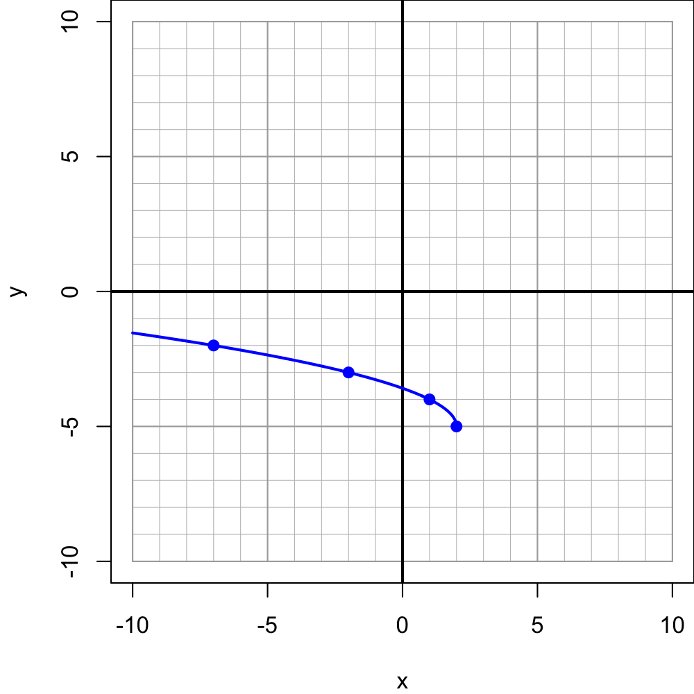

If standard algebraic steps were used to find $x$ values that satisfy equation $f(x)=L(x)$, what valid solution and what extraneous solution would be found?

- Valid:
- Extraneous:

You should be able to complete the picture. Use symmetry to complete the parabola, and use the slope to extend the line.

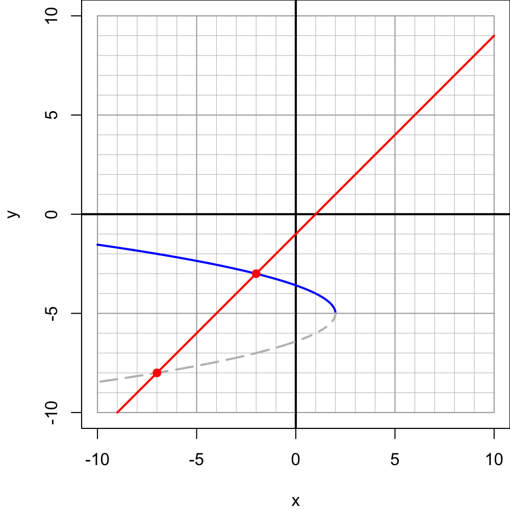

The intersection of the line with the valid half of the parabola is at point $(-2,-3)$. Thus the valid solution is $x=-2$.

The intersection of the line with the extraneous half of the parabola is at point $(-7,-8)$. Thus the extraneous solution is $x=-7$.

A transformed square-root function, $y=f(x)$, is graphed below. A linear function, $y=L(x)$, is not shown, but it goes through point $(-8,-8)$ and has a slope of $3$.

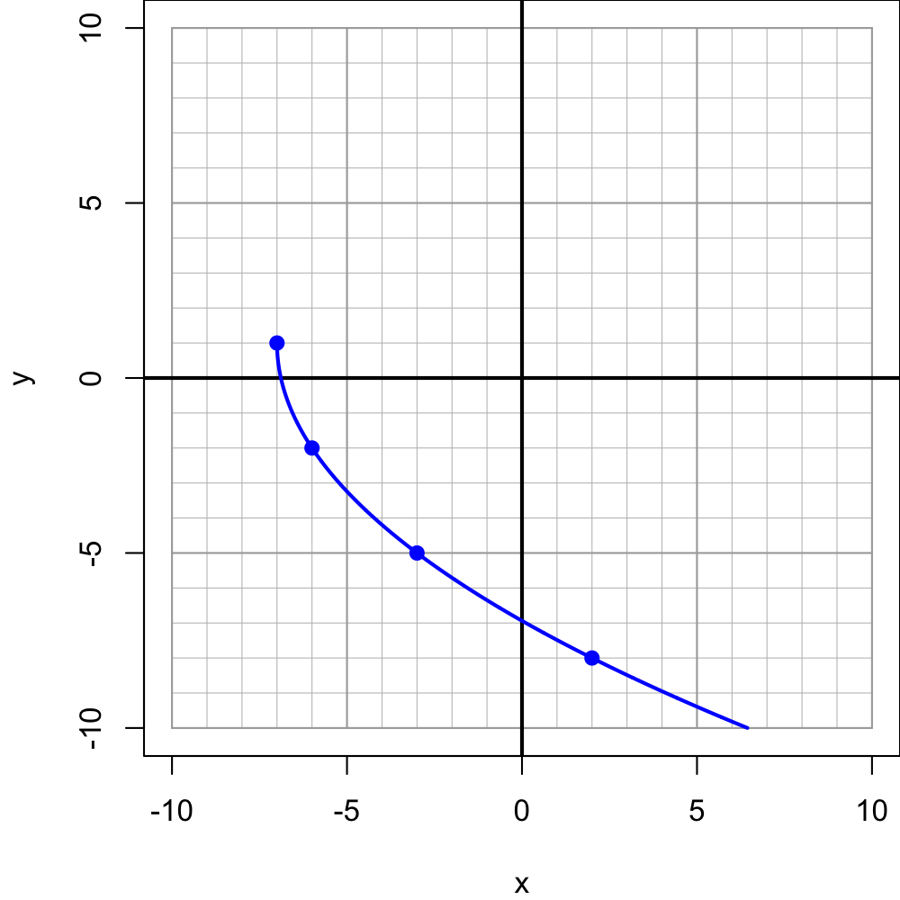

If standard algebraic steps were used to find $x$ values that satisfy equation $f(x)=L(x)$, what valid solution and what extraneous solution would be found?

- Valid:
- Extraneous:

You should be able to complete the picture. Use symmetry to complete the parabola, and use the slope to extend the line.

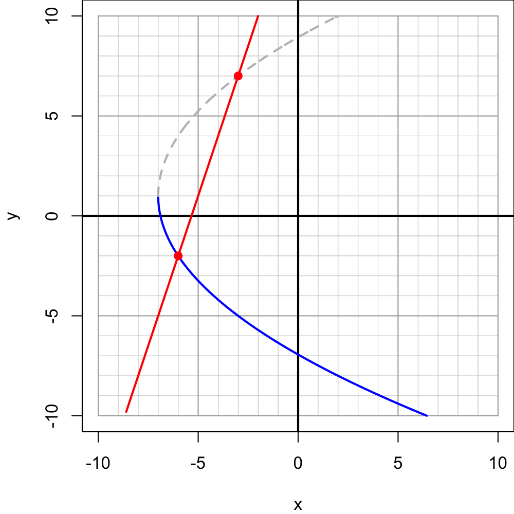

The intersection of the line with the valid half of the parabola is at point $(-6,-2)$. Thus the valid solution is $x=-6$.

The intersection of the line with the extraneous half of the parabola is at point $(-3,7)$. Thus the extraneous solution is $x=-3$.

A transformed square-root function, $y=f(x)$, is graphed below. A linear function, $y=L(x)$, is not shown, but it goes through point $(2,9)$ and has a slope of $-3$.

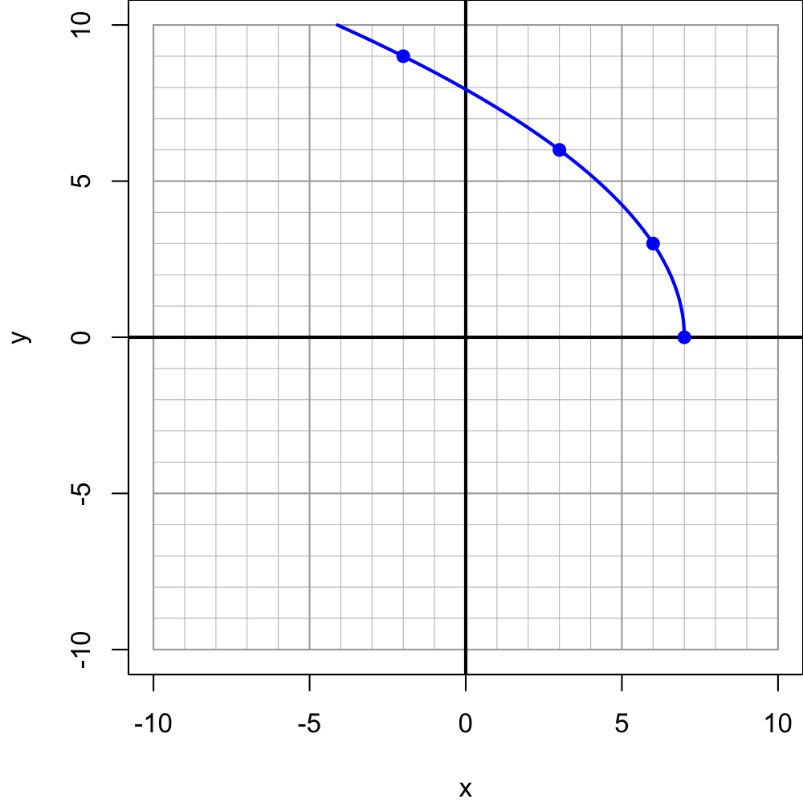

If standard algebraic steps were used to find $x$ values that satisfy equation $f(x)=L(x)$, what valid solution and what extraneous solution would be found?

- Valid:
- Extraneous:

You should be able to complete the picture. Use symmetry to complete the parabola, and use the slope to extend the line.

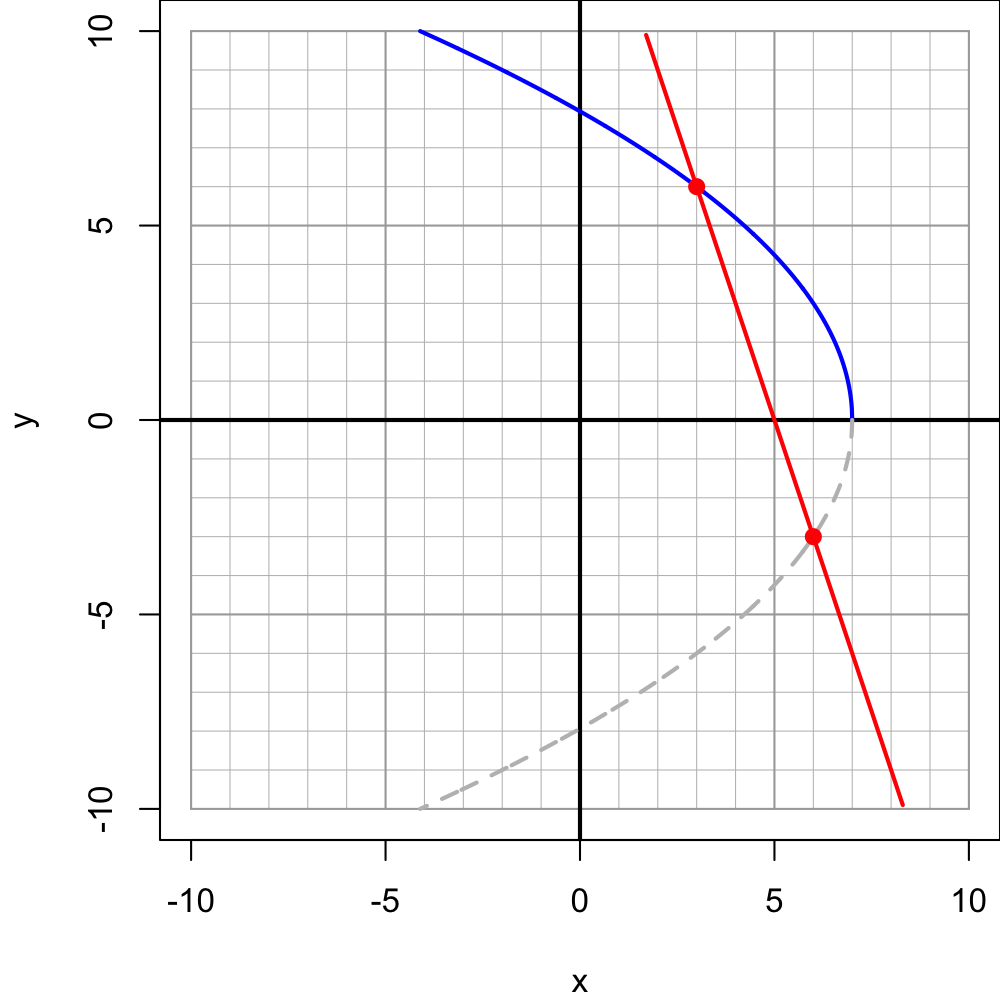

The intersection of the line with the valid half of the parabola is at point $(3,6)$. Thus the valid solution is $x=3$.

The intersection of the line with the extraneous half of the parabola is at point $(6,-3)$. Thus the extraneous solution is $x=6$.

A transformed square-root function, $y=f(x)$, is graphed below. A linear function, $y=L(x)$, is not shown, but it goes through point $(2,-1)$ and has a slope of $3$.

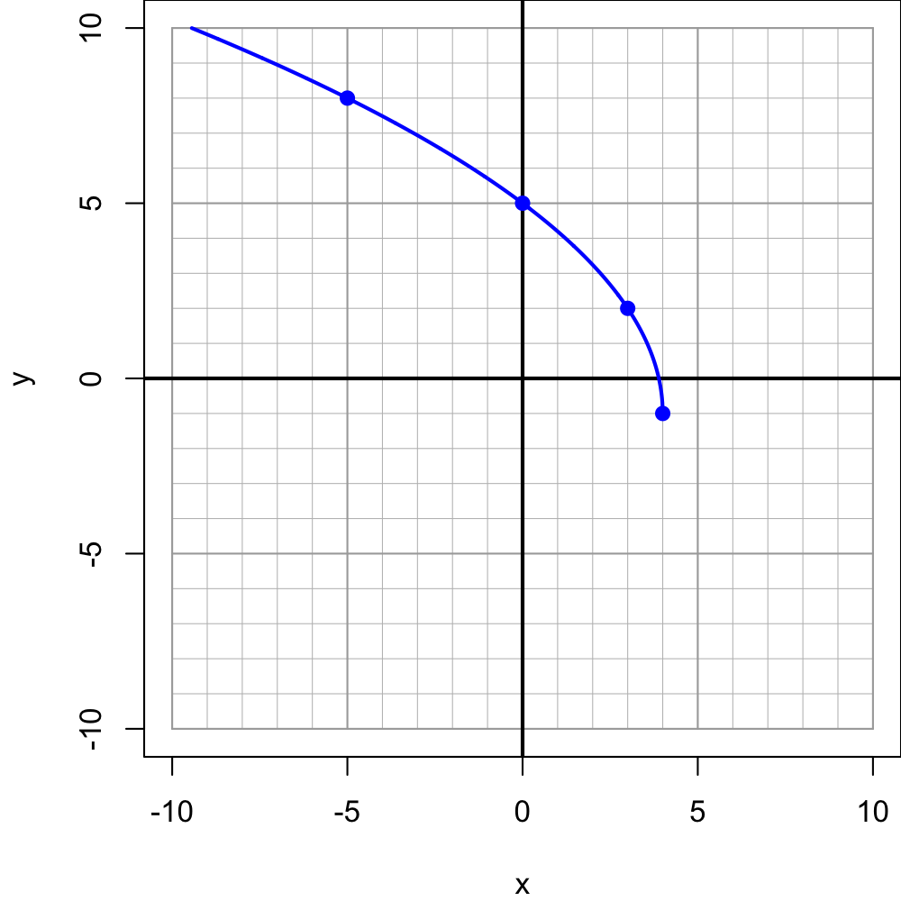

If standard algebraic steps were used to find $x$ values that satisfy equation $f(x)=L(x)$, what valid solution and what extraneous solution would be found?